# Report: Estimating the Impact of Groundwater Allocation Policies on Irrigation Behavior

Shunkei Kakimoto

# 1 Objective

- Quantify the heterogeneous impact of groundwater allocation policy on farmers’ irrigation activity in Nebraska, and reveal which factor is the main driver to cause such a heterogeneity.

# 2 Data

We used well-level groundwater extraction data focusing on two Nebraska’s Natural Resources Districts: Lower Republican (LR) and Tri-Basin(TB) during 2008-2015. Throughout the period, LR (treatment group) had an allocation of 9 acre-inches per year, while TB (control group) had no allocation. Furthermore, we used the wells located in a five-mile buffer from the border between LR and TB.

# 3 Method

- To estimate the treatment effect heterogeneity, we used Causal Forest (CF) model. CF is a machine learning methods developed specifically for identifying heterogeneous treatment effects (Athey and Imbens, 2016; Wager and Athey, 2018.)
- We employed cluster-robust estimation to take into account natural clusters in the data. Each cluster consists of time-series observations of the wells located within the same region.
- To predict the heterogeneous treatment effects precisely, we built two separate CFs. The first CF was used to select the most important variables in a data-driven way among many variables. The variable of importance is determined by how how often each variable is used to split nodes, in other words how often a variable is judged as a factor affecting treatment effect heterogeneity. Utilizing those information, only important variables selected in the 1st CF were used to the second CF modeling. This enables second CF to detect treatment effect heterogeneity easily, especially in low-signal situations, and it is expected that CF can produce more precise predictions (Athey and Wager, 2019.)

# 4 Results

```r
# === setup === #
library(here)
source(here("GitControlled/Codes/0_1_ls_packages.R"))
source(here("GitControlled/Codes/0_0_functions.R"))

# /*===== Data =====*/
reg_data <-
  here("Shared/Data/WaterAnalysis/comp_reg_dt.rds") %>%
  readRDS() %>%
  .[year>=2008 & usage <= 40,] %>%
  .[,tr_year:=factor(paste0(tr,year))] %>%
  .[,trs_year:=factor(paste0(trs,year))]

# agg_reg_data <-
#   copy(reg_data) %>%
#   .[year == 2012] %>%
#   # .[year %in% 2008:2009] %>%
#   # .[year %in% c(2008:2009, 2011:2012)] %>%
#   .[,.(
#     usage = sum(usage),
#     treat2 = mean(treat2),
#     # --- soil --- #
#     silttotal_r = mean(silttotal_r),
#     claytotal_r = mean(claytotal_r),
#     slope_r = mean(slope_r),
#     ksat_r = mean(ksat_r),
#     awc_r = mean(awc_r),
#     # --- weather --- #
#     pr_in = sum(pr_in),
#     pet_in = sum(pet_in),
#     gdd_in = sum(gdd_in),
#     # --- tr --- #
#     tr = tr
#     ),by=wellid] %>%
#   unique(.,by="wellid")


#/*--------------------------------*/
#' ## Preparation
#/*--------------------------------*/
# /*===== control variables =====*/
# remove gdd_in
cov_ls <- c(
  # --- weather --- #
  "pr_in","pet_in",
  # --- soil --- #
  "silttotal_r", "claytotal_r", "slope_r", "ksat_r", "awc_r"
  )


data <- reg_data
# data <- agg_reg_data

# /*===== Training Dataset  =====*/
# --- dependent variable --- #
Y <- data[, usage]
# --- treatment indicator --- #
T <- data[, treat2]
# --- features --- #
X <- data[, ..cov_ls]
# --- cluster  --- #
cl_var <- data[,tr_year]

#/*--------------------------------*/
#' ## 1st CF
#/*--------------------------------*/
set.seed(23456)

forest_W <- regression_forest(X, T, num.trees = 4000, clusters = cl_var)
W_hat <- predict(forest_W)$predictions

forest_Y <- regression_forest(X, Y, num.trees = 4000, clusters = cl_var)
Y_hat <- predict(forest_Y)$predictions

cf_raw <- causal_forest(
  X=X,
  Y=Y,
  W=T,
  Y.hat = Y_hat,
  W.hat = W_hat,
  clusters = cl_var,
  tune.parameters = "all",
  num.trees = 4000
)


# average_treatment_effect(cf_raw, target.sample = "treated")

varimp = variable_importance(cf_raw)
selected_vars = which(varimp > mean (varimp))
se_cov <- data[,cov_ls[selected_vars], with=FALSE]

vis_cf_raw <- gen_impact_viz(
  cf_res= cf_raw,
  data_base=data,
  treat_var='treat2',
  var_ls= cov_ls,
  var_ls_int = cov_ls
)

#/*--------------------------------*/
#' ## 2nd CF
#/*--------------------------------*/
cf_res <- causal_forest(
  X=se_cov,
  Y=Y,
  W=T,
  Y.hat = Y_hat,
  W.hat = W_hat,
  clusters = cl_var,
  sample.fraction = 0.4,
  num.trees = 4000
  # tune.parameters = "all",
  # tune.parameters = c(""),
)

#/*--------------------------------*/
#' ## Visualization
#/*--------------------------------*/
vis_cf_res <-
  gen_impact_viz(
  cf_res= cf_res,
  data_base=data,
  treat_var='treat2',
  var_ls= cov_ls[selected_vars],
  var_ls_int = cov_ls[selected_vars]
)
```

- The top row shows the histograms for each variable, and the bottom row shows the predicted treatment effects. Specifically, in each panel in the bottom row, the black line shows how the treatment effects varies, and the grey area indicates 95% CI for heterogeneous treatment effects.
- As a results of the covariate selection process, pr_in, pet_in, awc_r were selected.
- We found in-season total precipitation (`pr_in`) created strong heterogeneity in treatment effects. For regions where precipitation is low, farmers’ groundwater use was more strongly regulated, and the effects of the regulation became less in the regions where precipitation is high.
- This finding suggests that it is preferable to account for the spatial gradients in precipitation in designing groundwater allocation policy to achieve higher economic efficiency.

## 4.1 Compare

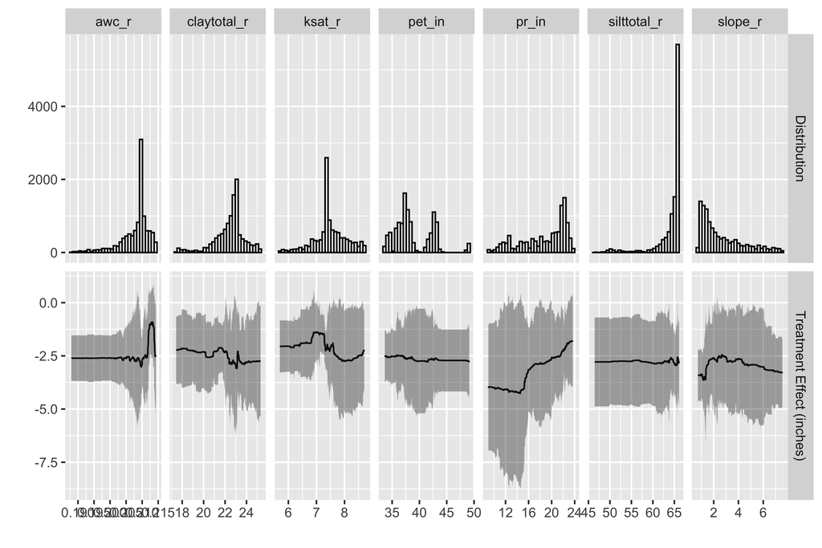

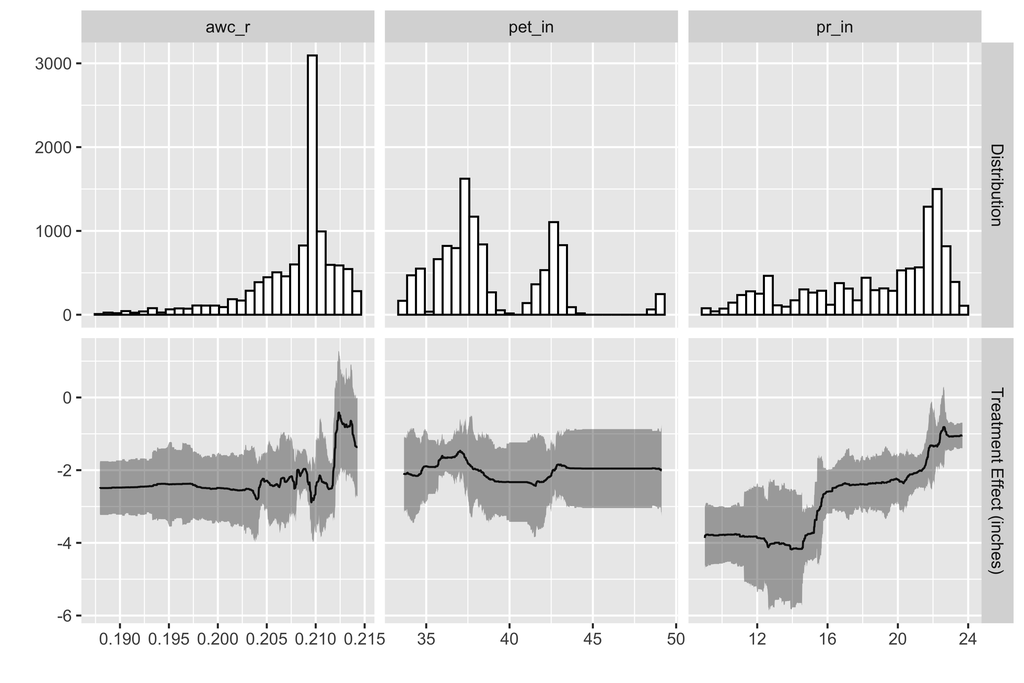

## 4.2 Further

- Although treatment assignments (9 acre-inches per year for LR, and no limitation on TB) are consistent through 2008-2015, this period has two allocation periods (1st period: 2008-2012, 2nd period: 2013-2017). In each allocation period, a farmer was allowed to carryover unused allocation into the next period.
  - So, for example, a farmer in LR can use 9 acre-inches per * 5 years = 45 acre-inches 2008-2012, and if he used only 30 acre-inches during 2008-2012, then he can use the remainder 15 inches for the next allocation period 2013-2017.
- This means that during the second period, it does not necessary mean that all the farmers in LR gets 9 acre-inches per year restriction. Some farmers who saved sizable amount of water might have used 10 acre-inches in the 2nd period. So, if we include the 2nd allocation period, the treatment effects would be underestimated. (?)
- (??In 2015, LR had a maximum use of 13 inches per acre)

## 4.3 About the heterogeneous treatment effects estimation

$$\begin{align}
Y &= \theta(X) \cdot T + g(X,W) + \varepsilon \quad E[\varepsilon|X,
W] = 0 \\
T &= f(X, W) + \eta \quad E[\eta|X, W] = 0 \\
E[\eta \cdot \varepsilon|X, W] = 0
\end{align}$$

- We use spatial discontinuity for treatment assignment, so it is likely that unconfoundedness assumption is likely to be satisfied.
- We are using precipitation, evapotranspiration, and soil characteristics as X, and W.
- Especially, we are suspecting that X (heterogeneous driver) is precipitation.
- Other factors?
  - Irrigation technology:
    - more efficient irrigation technology can alleviate the impact of precipitation.
    - irrigation technology and groundwater usage could be correlated
      - high irrigation technology can apply less amount of water to satisfy the water demand of field by minimizing the evaporation.